# United States Storm and Severe Weather Historic Event Analysis

Durgesh Verma

Feb 21, 2015

## Synopsis

This report analyze the storm and severe weather events happened in past (between Year 1950 and 2011) in United States. The data is sourced from U.S. National Oceanic and Atmospheric Administration’s (NOAA) storm database. Report helps to answer two major questions across United States * One is to analyze the most catastrophic events caused most fatalities and injuries to human population, * Another is to analyze the economic damage (property and corps) done by these events. The outcome of the analysis shows only top harmful events instead of showing all the events. The report can be useful for municipal managers who might be responsible for planning and prioritizing resources for severe weather events to reduce the risk of fatalities, injuries and other financial losses. Please note that report is not intended to suggest or recommend any solution to prepare for storm events.

## Initial Setup

### Set current working directory

```r
cur_dir <- "./"
setwd(cur_dir)
```

### Load required libraries

```r
library(ggplot2)
library(dplyr)
library(knitr)
```

## Data Processing

### Download data file

```r
filename <- 'StormData.csv.bz2'
if (!file.exists(filename)) {
    message("downloading file...")
    download.file('https://d396qusza40orc.cloudfront.net/repdata%2Fdata%2FStormData.csv.bz2', filename, method='curl')
}
```

### Load storm events data

```r
rawdata = read.table(bzfile(filename), sep=",", na.strings=c("NA","?"), header=TRUE)
head(rawdata, 3)
```

```
##   STATE__          BGN_DATE BGN_TIME TIME_ZONE COUNTY COUNTYNAME STATE
## 1       1 4/18/1950 0:00:00     0130       CST     97     MOBILE    AL
## 2       1 4/18/1950 0:00:00     0145       CST      3    BALDWIN    AL
## 3       1 2/20/1951 0:00:00     1600       CST     57    FAYETTE    AL
##    EVTYPE BGN_RANGE BGN_AZI BGN_LOCATI END_DATE END_TIME COUNTY_END
## 1 TORNADO         0                                               0
## 2 TORNADO         0                                               0
## 3 TORNADO         0                                               0
##   COUNTYENDN END_RANGE END_AZI END_LOCATI LENGTH WIDTH F MAG FATALITIES
## 1         NA         0                      14.0   100 3   0          0
## 2         NA         0                       2.0   150 2   0          0
## 3         NA         0                       0.1   123 2   0          0
##   INJURIES PROPDMG PROPDMGEXP CROPDMG CROPDMGEXP WFO STATEOFFIC ZONENAMES
## 1       15    25.0          K       0
## 2        0     2.5          K       0
## 3        2    25.0          K       0
##   LATITUDE LONGITUDE LATITUDE_E LONGITUDE_ REMARKS REFNUM
## 1     3040      8812       3051       8806              1
## 2     3042      8755          0          0              2
## 3     3340      8742          0          0              3
```

Data file has tabular data that contains 902297 rows and 37.

### Massage storm events data

```r
rawdata = select(mutate(subset(rawdata, select=c("BGN_DATE","EVTYPE","FATALITIES","INJURIES","PROPDMG","PROPDMGEXP","CROPDMG","CROPDMGEXP")), YEAR=as.numeric(format(as.Date(BGN_DATE, "%m/%d/%Y"), "%Y"))), -BGN_DATE)

rawdata = mutate(rawdata, prop_damage_amount = ifelse( (PROPDMGEXP=="k" | PROPDMGEXP=="K"), PROPDMG*1000, ifelse( (PROPDMGEXP=="m" | PROPDMGEXP=="M"), PROPDMG*1000000, ifelse( (PROPDMGEXP=="b" | PROPDMGEXP=="B"), PROPDMG*1000000000, ifelse( (PROPDMGEXP=="h" | PROPDMGEXP=="H"), PROPDMG*100, PROPDMG) ) ) ) )

rawdata = mutate(rawdata, crop_damage_amount = ifelse( (CROPDMGEXP=="k" | CROPDMGEXP=="K"), CROPDMG*1000, ifelse( (CROPDMGEXP=="m" | CROPDMGEXP=="M"), CROPDMG*1000000, ifelse( (CROPDMGEXP=="b" | CROPDMGEXP=="B"), CROPDMG*1000000000, ifelse( (CROPDMGEXP=="h" | CROPDMGEXP=="H"), CROPDMG*100, CROPDMG) ) ) ) )

rawdata <- mutate(rawdata, total_damage_amount = prop_damage_amount + crop_damage_amount )

rawdata = select(rawdata, -c(PROPDMGEXP,PROPDMG,CROPDMGEXP,CROPDMG))
```

Summary of data:

```r
kable(summary(rawdata), digits=2)
```

|  | EVTYPE | FATALITIES | INJURIES | YEAR | prop_damage_amount | crop_damage_amount | total_damage_amount |
| --- | --- | --- | --- | --- | --- | --- | --- |
|  | HAIL :288661 | Min. : 0.0000 | Min. : 0.0000 | Min. :1950 | Min. :0.000e+00 | Min. :0.000e+00 | Min. :0.00e+00 |
|  | TSTM WIND :219940 | 1st Qu.: 0.0000 | 1st Qu.: 0.0000 | 1st Qu.:1995 | 1st Qu.:0.000e+00 | 1st Qu.:0.000e+00 | 1st Qu.:0.00e+00 |
|  | THUNDERSTORM WIND: 82563 | Median : 0.0000 | Median : 0.0000 | Median :2002 | Median :0.000e+00 | Median :0.000e+00 | Median :0.00e+00 |
|  | TORNADO : 60652 | Mean : 0.0168 | Mean : 0.1557 | Mean :1999 | Mean :4.736e+05 | Mean :5.442e+04 | Mean :5.28e+05 |
|  | FLASH FLOOD : 54277 | 3rd Qu.: 0.0000 | 3rd Qu.: 0.0000 | 3rd Qu.:2007 | 3rd Qu.:5.000e+02 | 3rd Qu.:0.000e+00 | 3rd Qu.:1.00e+03 |
|  | (Other) :196203 | Max. :583.0000 | Max. :1700.0000 | Max. :2011 | Max. :1.150e+11 | Max. :5.000e+09 | Max. :1.15e+11 |
|  | NA’s : 1 | NA | NA | NA | NA’s :8 | NA’s :7 | NA’s :15 |

### Part 1 - Across the United States, which types of events (as indicated in the EVTYPE variable) are most harmful with respect to population health?

#### Process storm events data to identify most harmful events

```r
q1_f=aggregate(rawdata$FATALITIES, by=list(rawdata$EVTYPE), sum)
colnames(q1_f) = c("EVTYPE", "COUNT")
q1_f$type <- rep(c("FATALITIES"), nrow(q1_f))

q1_i=aggregate(rawdata$INJURIES, by=list(rawdata$EVTYPE), sum)
colnames(q1_i) = c("EVTYPE", "COUNT")
q1_i$type <- rep(c("INJURIES"), nrow(q1_i))

q1_top50 = rbind(head(q1_f[order(q1_f$COUNT, q1_f$EVTYPE, na.last=TRUE, decreasing=TRUE),], 25), head(q1_i[order(q1_i$COUNT, q1_i$EVTYPE, na.last=TRUE, decreasing=TRUE),], 25), deparse.level = 0)
rownames(q1_top50) = NULL
```

#### Plot charts to show most harmful events

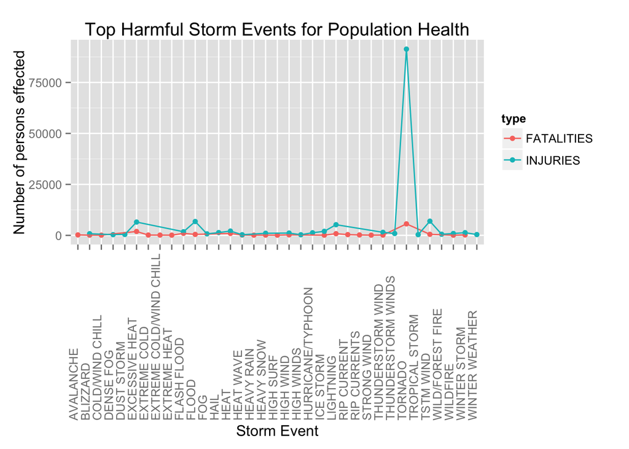

```r
p = qplot(EVTYPE, COUNT, data=q1_top50, color=type) + geom_line(aes(group=type)) + labs(title="Top Harmful Storm Events for Population Health", x="Storm Event", y="Number of persons effected") + theme(axis.text.x=element_text(angle=90, hjust=0, vjust=0))
print(p)
```

#### `Results` - Part 1

- Top 5 storm events causing most fatalities

```r
res = head(subset(q1_top50, select=c("EVTYPE","COUNT"), type=="FATALITIES"), 5)
colnames(res) = c("Event","Number of Fatalities")
print(res)
```

```
##            Event Number of Fatalities
## 1        TORNADO                 5633
## 2 EXCESSIVE HEAT                 1903
## 3    FLASH FLOOD                  978
## 4           HEAT                  937
## 5      LIGHTNING                  816
```

- Top 5 storm events causing most injuries

```r
res = head(subset(q1_top50, select=c("EVTYPE","COUNT"), type=="INJURIES"), 5)
colnames(res) = c("Event","Number of Injuries")
print(res)
```

```
##             Event Number of Injuries
## 26        TORNADO              91346
## 27      TSTM WIND               6957
## 28          FLOOD               6789
## 29 EXCESSIVE HEAT               6525
## 30      LIGHTNING               5230
```

Clean up memory

```r
rm(q1_f, q1_i, q1_top50, p)
```

### Part 2 - Across the United States, which types of events have the greatest economic consequences?

#### Processing storm data to identify events caused greatest economic consequences

```r
q2 = subset(aggregate(cbind(total_damage_amount, prop_damage_amount, crop_damage_amount) ~ EVTYPE, data = rawdata, sum), total_damage_amount>0)
q2 = q2[order(q2$total_damage_amount, q2$EVTYPE, na.last=TRUE, decreasing=TRUE),]
rownames(q2) = NULL

q3 = head(q2,25)
q31 = subset(q3, select=c("EVTYPE", "prop_damage_amount"))
colnames(q31) = c("EVTYPE", "DAMAGE_AMOUNT")
q31$type <- rep(c("Property"), nrow(q31))

q32 = subset(q3, select=c("EVTYPE", "crop_damage_amount"))
colnames(q32) = c("EVTYPE", "DAMAGE_AMOUNT")
q32$type <- rep(c("Crop"), nrow(q32))

q3 = rbind(q31, q32)
rm(q31, q32)
```

#### Plotting charts to show events caused greatest economic consequences

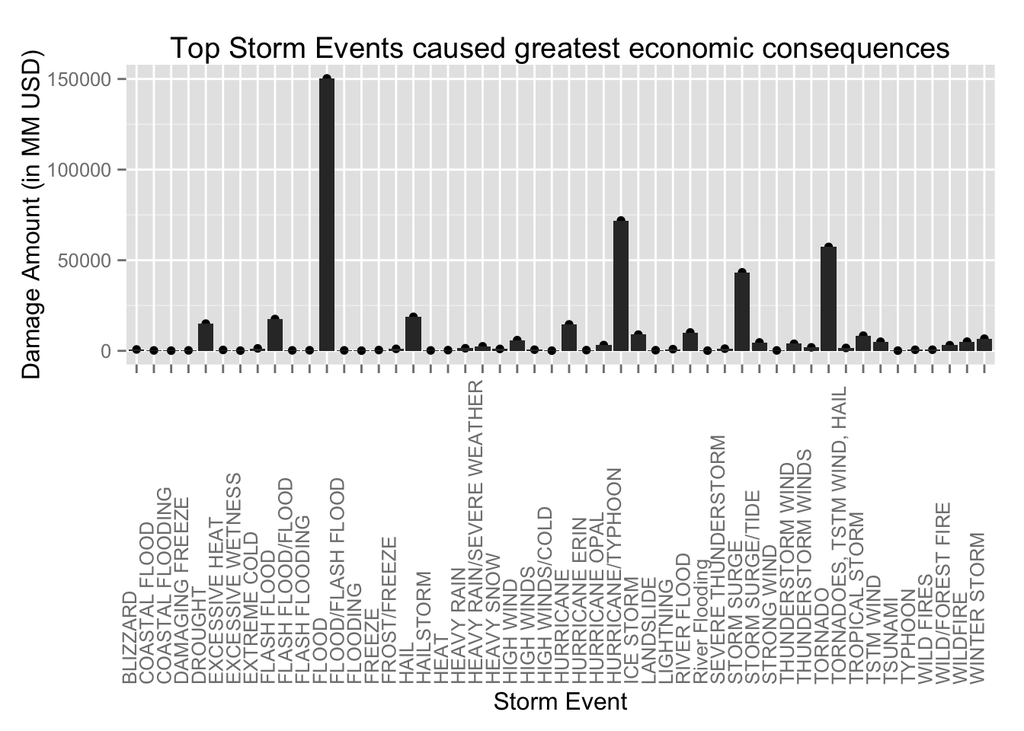

```r
p=qplot(EVTYPE, total_damage_amount/1000000, data=head(q2,50))+geom_bar(stat="identity")+labs(title="Top Storm Events caused greatest economic consequences", x="Storm Event", y="Damage Amount (in MM USD)")+theme(axis.text.x=element_text(angle=90, hjust=0, vjust=0))
print(p)
```

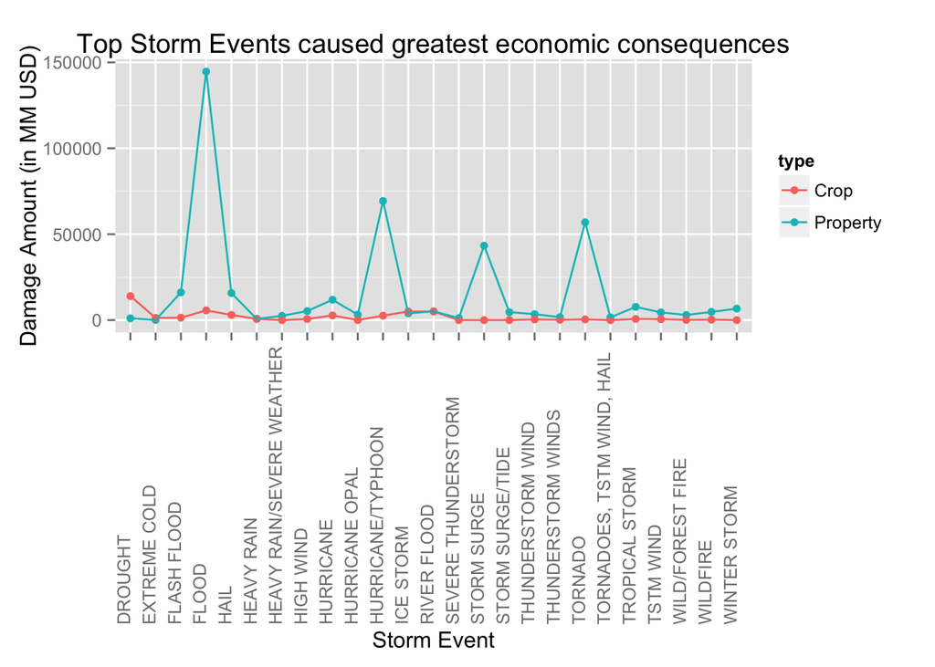

```r
p=qplot(EVTYPE, DAMAGE_AMOUNT/1000000, data=q3, color=type)+geom_line(aes(group=type))+labs(title="Top Storm Events caused greatest economic consequences", x="Storm Event", y="Damage Amount (in MM USD)")+theme(axis.text.x=element_text(angle=90, hjust=0, vjust=0))
print(p)
```

#### `Results` - Part 2

- Top 5 storm events causing most financial damage

```r
res = head(q2, 5)
colnames(res) = c("Event","Total Damage Amount (in USD)","Property Damage Amount (in USD)","Corps Damage Amount (in USD)")
print(res)
```

```
##               Event Total Damage Amount (in USD)
## 1             FLOOD                 150319678257
## 2 HURRICANE/TYPHOON                  71913712800
## 3           TORNADO                  57352114049
## 4       STORM SURGE                  43323541000
## 5              HAIL                  18758222016
##   Property Damage Amount (in USD) Corps Damage Amount (in USD)
## 1                    144657709807                   5661968450
## 2                     69305840000                   2607872800
## 3                     56937160779                    414953270
## 4                     43323536000                         5000
## 5                     15732267543                   3025954473
```

Clean up memory

```r
rm(q2, q3, p, res)
```